# HW 12: Dates

William Zoughaib

30 July 2020

```r
library(tidyverse)
library(here)
library(lubridate)
```

### Part 1: Play Date (copied and pasted)

```r
birth_date <- "05/14/1998"

# Elizabeth Garret Anderson was the first female physician
anderson <- "9 June 1836"

# Mary Anning discovered the first complete Plesiosaur fossil,
# and other important Jurassic fossils
anning <-  "1799/05/21"

# Alice Augusta Ball was a chemist who developed the
# first injectable treatment for leprosy.
ball <- "July 24, 1892"

# Sylvia Earle was the first chieft scientist at NOAA
earle <- "August, 30 (1935)"

# Rosalind Franklin used x-ray diffraction to
# discover DNA structure. Watson and Crick claimed credit.
franklin <- "25th of July, 1920"

# Ester Lederberg was the first to discover that viruses
# infect bacteria. Led to discovery of lambda bacteriophage
lederberg <- "December 18, 1922"

# Barbara McClintock discovered transposable elements (jumping genes),
# and developed staining techniques to study chromosomes
mcclintock <- "16061902"

# Let's also remember a dream
mlk_birth <- "1/15/29"
mlk_dream <- "1963 August 28"
```

#### Convert each date to POSIXct format, using lubridate functions, saving each to a unique variable. (I guess I am adding a time of day?)

```r
birth_time <- mdy(birth_date)
birth_time
```

```
[1] "1998-05-14"
```

```r
# I really dont know when I was born.
anderson_time <- dmy(anderson)
anderson_time
```

```
[1] "1836-06-09"
```

```r
# Interesting.  You only hear about the nurses during that time period.
anning_time <- ymd(anning)
anning_time
```

```
[1] "1799-05-21"
```

```r
# I would hunt for fossils in the afternoon
ball_time <- mdy(ball)
ball_time
```

```
[1] "1892-07-24"
```

```r
# I am most preductive with science in the morning
earle_time <- mdy(earle)
earle_time
```

```
[1] "1935-08-30"
```

```r
# Lunch time
franklin_time <- dmy(franklin)
franklin_time
```

```
[1] "1920-07-25"
```

```r
# nasty little hobbitses
lederberg_time <- mdy(lederberg)
lederberg_time
```

```
[1] "1922-12-18"
```

```r
# oof, i ran out
mcclintock_time <- dmy(mcclintock)
mcclintock_time
```

```
[1] "1902-06-16"
```

```r
# This time is confusing
mlk_birth_time <- mdy(mlk_birth)
mlk_birth_time
```

```
[1] "2029-01-15"
```

```r
mlk_dream_time <- ymd(mlk_dream)
mlk_dream_time
```

```
[1] "1963-08-28"
```

```r
# Pertinent
```

#### Check yours dates to be sure they are correct. If you spot any errors, correct them now using the proper lubridate function(s).

```r
mlk_birth.1 <- "01/15/1929"
mlk_birth_time.1 <- mdy(mlk_birth.1)
mlk_birth_time.1
```

```
[1] "1929-01-15"
```

```r
# edited birth year from 2029 to 1929.
```

#### What day of the week were you born on? Show the full day name, not the abbreviated name or the day number.

```r
wday(birth_time,label=TRUE,abbr=FALSE)
```

```
[1] Thursday
7 Levels: Sunday < Monday < Tuesday < ... < Saturday
```

```r
# Thursday was the day I was born on.
```

####What day of the week will your birthday be on this year? Use lubridate’s update function. You must figure out how to do it entirely by code for full points (no hard-coding). In other words, you code should work just as well next year or five years in the future, without editing.`

```r
find_my_day_birth <- function(year,month,day){
  update(birth_time,year,month,day)}
  wday(find_my_day_birth(year=2020,month=5,day=14),label=TRUE,abbr=FALSE)
```

```
[1] Thursday
7 Levels: Sunday < Monday < Tuesday < ... < Saturday
```

```r
# I am really confused by this.  This is the only way I could get it to work without errors. My birthday fell on a Thursday this year.
```

```r
wday(find_my_day_birth(year=2024,month=5,day=14),label=TRUE,abbr=FALSE)
```

```
[1] Tuesday
7 Levels: Sunday < Monday < Tuesday < ... < Saturday
```

```r
  # THis still works
```

```r
wday(find_my_day_birth(year=2020,month=10,day=5),label=TRUE,abbr=FALSE)
```

```
[1] Monday
7 Levels: Sunday < Monday < Tuesday < ... < Saturday
```

```r
  # using Mom's birthdate, it still works.
```

```r
wday(find_my_day_birth(year=2020,month=4,day=26),label=TRUE,abbr=FALSE)
```

```
[1] Sunday
7 Levels: Sunday < Monday < Tuesday < ... < Saturday
```

```r
# My sisters still works.  Sorry for all these extra code chunks.
```

#### What day of the week would your birthday be on in the Year 2525, if Man is still alive? How old would you be? Here you may hard-code 2525. Show the abbreviated day of the week.

```r
wday(update(birth_time,year=2525),label=TRUE)
```

```
[1] Mon
7 Levels: Sun < Mon < Tue < Wed < Thu < ... < Sat
```

```r
# Hard code
```

```r
wday(find_my_day_birth(year=2525,month=5,day=14),label=TRUE)
```

```
[1] Mon
7 Levels: Sun < Mon < Tue < Wed < Thu < ... < Sat
```

```r
# Using my find_my_day_birth function
```

#### How many days was it between the birth of Dr. Elizabeth Garrett Anderson and Alice Augusta Ball?

```r
anderson_time-ball_time
```

```
Time difference of -20499 days
```

```r
# approximately 20499 days between their births
```

#### What is the duration between Martin Luther King Jr.’s birth date and his I Had a Dream speech.

```r
mlk_birth_time.1-mlk_dream_time
```

```
Time difference of -12643 days
```

```r
# approximately 12643 days
```

####Enter the eight POSIXct compatible birth dates, including your own, into a vector in the order they are given above. Name each element of the vector with the last name of each person (review Assignment 2, part 2). You can but do not have to enter the date of the Dream speech.

```r
all_birth_dates <- c(birth_time,anderson_time,anning_time,ball_time,earle_time,franklin_time,lederberg_time,mcclintock_time,mlk_birth_time.1,mlk_dream_time)
all_birth_dates
```

```
 [1] "1998-05-14" "1836-06-09" "1799-05-21"
 [4] "1892-07-24" "1935-08-30" "1920-07-25"
 [7] "1922-12-18" "1902-06-16" "1929-01-15"
[10] "1963-08-28"
```

#### Of the eight birth dates from above, including your own, which of them are leap years? You must start with the POSIXct dates in your vector, and display the final result as only the years of the leap years, not the date. You should end up with 3-4 years, depending on whether your birth year was a leap year. If your results show the full birth dates, then you need to apply one of the lubridate functions.

```r
year <- year(all_birth_dates)
year
```

```
 [1] 1998 1836 1799 1892 1935 1920 1922 1902 1929 1963
```

```r
leap_year(year)
```

```
 [1] FALSE  TRUE FALSE  TRUE FALSE  TRUE FALSE FALSE
 [9] FALSE FALSE
```

```r
# This is the only way I could figure it out.  I even went to parts 4 and 5 of CH16.  1836, 1892, 1920 are the leap years.
```

#### Subtract each birth date in the vector from your own to calculate the number of days that have passed between their birth dates and yours. Sort the results from greatest number of days to fewest. You should be listed last (or near the end) with a difference of 0 days.

```r
diff_days <- birth_time-all_birth_dates
sort(diff_days,decreasing = TRUE)
```

```
Time differences in days
 [1] 72676 59143 38644 35031 28417 27541 25321 22903
 [9] 12678     0
```

### Part 2: Wrangling and plotting with dates

#### Import Plot 1 Lake Ice

```r
lake_data <- read_csv(here::here("data","lake_ice.csv"),na="-999") %>%
drop_na()
lake_data
```

| lakecode | lakename | lakeorriver | season | iceon_year | iceon_month | iceon_day | iceoff_year | iceoff_month | iceoff_day | duration | latitude | longitude | country | froze | comments |
| --- | --- | --- | --- | --- | --- | --- | --- | --- | --- | --- | --- | --- | --- | --- | --- |
| ARAI1 | LAKE SUWA | L | 1944-45 | 1945 | 1 | 3 | 1945 | 3 | 28 | 80 | 36.15 | 138.08 | JAPAN | Y |  |
| ARAI1 | LAKE SUWA | L | 1945-46 | 1945 | 12 | 27 | 1946 | 3 | 6 | 76 | 36.15 | 138.08 | JAPAN | Y |  |
| ARAI1 | LAKE SUWA | L | 1946-47 | 1947 | 1 | 4 | 1947 | 3 | 12 | 68 | 36.15 | 138.08 | JAPAN | Y |  |
| ARAI1 | LAKE SUWA | L | 1947-48 | 1947 | 12 | 20 | 1948 | 2 | 27 | 70 | 36.15 | 138.08 | JAPAN | Y |  |
| ARAI1 | LAKE SUWA | L | 1949-50 | 1950 | 1 | 12 | 1950 | 1 | 31 | 33 | 36.15 | 138.08 | JAPAN | Y |  |
| ARAI1 | LAKE SUWA | L | 1950-51 | 1950 | 12 | 29 | 1951 | 2 | 25 | 59 | 36.15 | 138.08 | JAPAN | Y |  |
| ARAI1 | LAKE SUWA | L | 1951-52 | 1952 | 1 | 13 | 1952 | 3 | 27 | 75 | 36.15 | 138.08 | JAPAN | Y |  |
| ARAI1 | LAKE SUWA | L | 1952-53 | 1952 | 12 | 25 | 1953 | 3 | 4 | 57 | 36.15 | 138.08 | JAPAN | Y | preferred is date from weather station: 5 January 1953 (J.Magnuson 1 Feb 2012) |
| ARAI1 | LAKE SUWA | L | 1953-54 | 1954 | 1 | 25 | 1954 | 2 | 27 | 34 | 36.15 | 138.08 | JAPAN | Y |  |
| ARAI1 | LAKE SUWA | L | 1954-55 | 1955 | 1 | 4 | 1955 | 3 | 3 | 59 | 36.15 | 138.08 | JAPAN | Y |  |

[output cut: 990 more lines]

```r
# no where could i find how to drop -999.  I googled it and could not find anything concrete.  I decided to just remove the columns then.
```

#### Wrangle by selecting the iceon_… and iceoff_ columns. Filter LAKE MENDOTA. Create duration column.

```r
tidy_lake_data <- filter(lake_data,lakename=="LAKE MENDOTA") %>%
  select(c(iceon_year,iceon_month,iceon_day,iceoff_year,iceoff_month,iceoff_day)) %>%
  mutate(ice_on=make_date(iceon_year,iceon_month,iceon_day),
         ice_off=make_date(iceoff_year,iceoff_month,iceoff_day),
         duration=as.numeric(ice_off-ice_on))
tidy_lake_data
```

| iceon_year | iceon_month | iceon_day | iceoff_year | iceoff_month | iceoff_day | ice_on | ice_off | duration |
| --- | --- | --- | --- | --- | --- | --- | --- | --- |
| 1855 | 12 | 18 | 1856 | 4 | 14 | 1855-12-18 | 1856-04-14 | 118 |
| 1856 | 12 | 6 | 1857 | 5 | 6 | 1856-12-06 | 1857-05-06 | 151 |
| 1857 | 11 | 25 | 1858 | 3 | 26 | 1857-11-25 | 1858-03-26 | 121 |
| 1858 | 12 | 8 | 1859 | 3 | 14 | 1858-12-08 | 1859-03-14 | 96 |
| 1859 | 12 | 7 | 1860 | 3 | 26 | 1859-12-07 | 1860-03-26 | 110 |
| 1860 | 12 | 14 | 1861 | 4 | 10 | 1860-12-14 | 1861-04-10 | 117 |
| 1861 | 12 | 2 | 1862 | 4 | 13 | 1861-12-02 | 1862-04-13 | 132 |
| 1862 | 12 | 26 | 1863 | 4 | 9 | 1862-12-26 | 1863-04-09 | 104 |
| 1863 | 12 | 18 | 1864 | 4 | 21 | 1863-12-18 | 1864-04-21 | 125 |
| 1864 | 12 | 8 | 1865 | 4 | 5 | 1864-12-08 | 1865-04-05 | 118 |

[output cut: 148 more lines]

#### Plot with a line graph of duration v iceoff_year

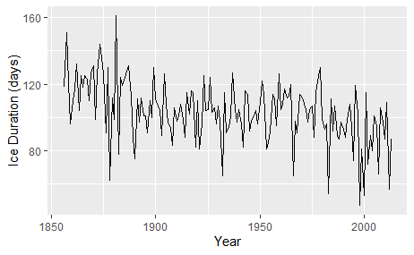

```r
tidy_lake_data %>%
  ggplot()+
  geom_line(aes(x=iceoff_year,y=duration),na.rm=TRUE)+
  labs(x="Year",
    y="Ice Duration (days)")
```

```r
# I think I got it.
```

#### Import Plot 2 Soil Carbon Dioxide

```r
soil_data <- read_tsv(here::here("data","soil_co2.txt"))
soil_data
```

| DayN[] | Datecode[] | Min[] | Veg[] | Plot[] | Group[] | CorrCO2[] | SoilT[] |
| --- | --- | --- | --- | --- | --- | --- | --- |
| 481 | 1 | 0 | 1 | 6 | 1 | 398.18 | 291.1 |
| 481 | 1 | 15 | 1 | 6 | 1 | 510.06 | 291.1 |
| 481 | 1 | 30 | 1 | 6 | 1 | 499.62 | 291.1 |
| 481 | 1 | 0 | 1 | 18 | 2 | 474.52 | 290.8 |
| 481 | 1 | 15 | 1 | 18 | 2 | 674.17 | 290.8 |
| 481 | 1 | 30 | 1 | 18 | 2 | 763.96 | 290.8 |
| 481 | 1 | 0 | 1 | 14 | 3 | 801.90 | 289.3 |
| 481 | 1 | 15 | 1 | 14 | 3 | 764.36 | 289.3 |
| 481 | 1 | 30 | 1 | 14 | 3 | 830.51 | 289.3 |
| 481 | 1 | 0 | 1 | 10 | 4 | 404.05 | 290.8 |

[output cut: 990 more lines]

#### Make a POSIXct date for 01 January 2006

```r
soil_date <- dmy("01 January 2006")
soil_date
```

[output not shown]

#### Wrangle by renaming columns, creating a Date column, a Year column, a Month column

```r
soil_co2_data <- soil_data %>%
  rename("Day"=`DayN[]`,"Date_code"=`Datecode[]`,"Min"=`Min[]`,"Veg"=`Veg[]`,"Plot"=`Plot[]`,"Group"=`Group[]`,"Corr_CO2"=`CorrCO2[]`,"Soil_T"=`SoilT[]`) %>%
  mutate(Date=soil_date+Day,
         Year=year(Date),
         Month=month(Date,label=TRUE))
soil_co2_data
```

| Day | Date_code | Min | Veg | Plot | Group | Corr_CO2 | Soil_T | Date | Year | Month |
| --- | --- | --- | --- | --- | --- | --- | --- | --- | --- | --- |
| 481 | 1 | 0 | 1 | 6 | 1 | 398.18 | 291.1 | 2007-04-27 | 2007 | Apr |
| 481 | 1 | 15 | 1 | 6 | 1 | 510.06 | 291.1 | 2007-04-27 | 2007 | Apr |
| 481 | 1 | 30 | 1 | 6 | 1 | 499.62 | 291.1 | 2007-04-27 | 2007 | Apr |
| 481 | 1 | 0 | 1 | 18 | 2 | 474.52 | 290.8 | 2007-04-27 | 2007 | Apr |
| 481 | 1 | 15 | 1 | 18 | 2 | 674.17 | 290.8 | 2007-04-27 | 2007 | Apr |
| 481 | 1 | 30 | 1 | 18 | 2 | 763.96 | 290.8 | 2007-04-27 | 2007 | Apr |
| 481 | 1 | 0 | 1 | 14 | 3 | 801.90 | 289.3 | 2007-04-27 | 2007 | Apr |
| 481 | 1 | 15 | 1 | 14 | 3 | 764.36 | 289.3 | 2007-04-27 | 2007 | Apr |
| 481 | 1 | 30 | 1 | 14 | 3 | 830.51 | 289.3 | 2007-04-27 | 2007 | Apr |
| 481 | 1 | 0 | 1 | 10 | 4 | 404.05 | 290.8 | 2007-04-27 | 2007 | Apr |

[output cut: 990 more lines]

```r
# Rename the columns by removing the [],
```

#### USe Group for Year and Month on soil_CO2_data. Summarize mean CO2 and use std_err function (i created this)

```r
source(here("scripts","my_functions.R"))
```

```r
group_soil_data <- group_by(soil_co2_data,Year,Month)
sum_soil_data <- summarise(group_soil_data,meanCO2=mean(Corr_CO2,na.rm = TRUE),std_err_CO2=std_err(Corr_CO2,na.rm=TRUE),.groups = 'drop')
sum_soil_data
```

| Year | Month | meanCO2 | std_err_CO2 |
| --- | --- | --- | --- |
| 2007 | Apr | 610.3469 | 18.16704 |
| 2007 | May | 878.8084 | 16.55794 |
| 2007 | Jun | 1039.9411 | 25.53794 |
| 2007 | Jul | 970.0604 | 31.19578 |
| 2007 | Aug | 1115.6591 | 53.41010 |
| 2007 | Sep | 1004.7191 | 30.35294 |
| 2007 | Oct | 686.1444 | 14.27253 |
| 2008 | Apr | 640.8884 | 12.27243 |
| 2008 | May | 961.0424 | 32.14498 |
| 2008 | Jun | 1151.2460 | 36.37925 |

[output cut: 26 more lines]

#### Plot with an errorbar over geom_col. Use std_error with mean_CO2

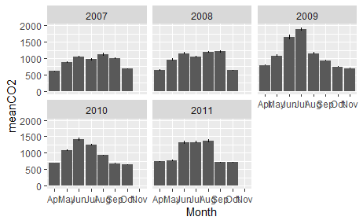

```r
ggplot(data=sum_soil_data)+
  geom_col(mapping=aes(x=Month,y=meanCO2))+
  geom_linerange(aes(x=Month,ymin=meanCO2-std_err_CO2,ymax=meanCO2+std_err_CO2))+
facet_wrap(~Year)
```

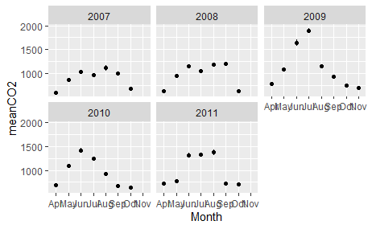

```r
ggplot(data=sum_soil_data)+
  geom_point(mapping=aes(x=Month,y=meanCO2))+
  geom_linerange(aes(x=Month,ymin=meanCO2-std_err_CO2,ymax=meanCO2+std_err_CO2))+
facet_wrap(~Year)
```

```r
# This again looks ok.
```

#### Import Plot 3 Mississippi River Discharge. Wrangle: Add Year column by moving 1988:2018 using pivot_longer (creates more rows). Add and then change Discharge column to show values divided by 1000

```r
river_data <- read_csv(here("data","thebes_discharge.csv"))
thebes_river_data <- pivot_longer(river_data,"1988":"2018",names_to="Year",values_to = "Discharge") %>%
  mutate(Discharge=Discharge/1000)
thebes_river_data
```

| Month | Day | Year | Discharge |
| --- | --- | --- | --- |
| 1 | 1 | 1988 | 371.0 |
| 1 | 1 | 1989 | 134.0 |
| 1 | 1 | 1990 | 54.5 |
| 1 | 1 | 1991 | 256.0 |
| 1 | 1 | 1992 | 205.0 |
| 1 | 1 | 1993 | 279.0 |
| 1 | 1 | 1994 | 143.0 |
| 1 | 1 | 1995 | 135.0 |
| 1 | 1 | 1996 | 108.0 |
| 1 | 1 | 1997 | 132.0 |

[output cut: 990 more lines]

#### Group by Year and Month. Summarize mean discharge. Remember to use na.rm=TRUE. Use Mutate and case_when for new column Event

```r
group_river_data <- group_by(thebes_river_data,Year,Month)
sum_river_data <- summarise(group_river_data,mean_discharge=mean(Discharge,na.rm=TRUE),.groups='drop') %>%
  mutate(Event=case_when(
    Year==1993|Year==2011 ~ "Flood",
    Year==1988|Year==2012 ~ "Drought",
    TRUE~"Normal")) %>%
  mutate(Month=month(Month,label=TRUE))
sum_river_data
```

| Year | Month | mean_discharge | Event |
| --- | --- | --- | --- |
| 1988 | Jan | 189.38710 | Drought |
| 1988 | Feb | 211.20690 | Drought |
| 1988 | Mar | 211.19355 | Drought |
| 1988 | Apr | 266.76667 | Drought |
| 1988 | May | 140.06452 | Drought |
| 1988 | Jun | 83.85667 | Drought |
| 1988 | Jul | 73.60000 | Drought |
| 1988 | Aug | 71.63871 | Drought |
| 1988 | Sep | 75.86000 | Drought |
| 1988 | Oct | 76.96452 | Drought |

[output cut: 362 more lines]

#### Second data set. Try and use %in% for years 1988,1993,2011,2012. 48 rows should appear

```r
river_events <- sum_river_data %>%
  filter(Year%in%c(1988,1993,2011,2012))
river_events
```

| Year | Month | mean_discharge | Event |
| --- | --- | --- | --- |
| 1988 | Jan | 189.38710 | Drought |
| 1988 | Feb | 211.20690 | Drought |
| 1988 | Mar | 211.19355 | Drought |
| 1988 | Apr | 266.76667 | Drought |
| 1988 | May | 140.06452 | Drought |
| 1988 | Jun | 83.85667 | Drought |
| 1988 | Jul | 73.60000 | Drought |
| 1988 | Aug | 71.63871 | Drought |
| 1988 | Sep | 75.86000 | Drought |
| 1988 | Oct | 76.96452 | Drought |

[output cut: 38 more lines]

```r
# I forgot to use c() with %in%.
```

#### Plot the mini data set: river_events over main sum_river_data set

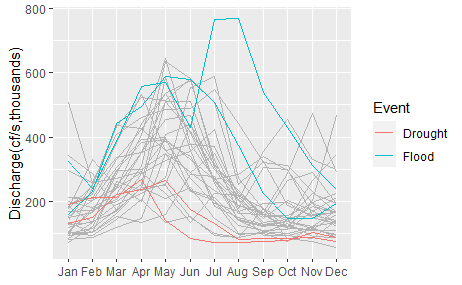

```r
ggplot(data=sum_river_data)+
  geom_line(mapping=aes(x=Month,y=mean_discharge,group=Year),size=0.3,color="grey70")+
  geom_line(river_events,mapping = aes(Month,mean_discharge,group=Year,color=Event))+
labs(x=NULL,
     y="Discharge(cf/s,thousands)")
```

```r
# Remember to use group= or you will waste an hour trying to figure out how to include years in plot....
```

#### **THE END. THIS TOOK FOREVER!!! I FEEL REALLY DUMB SOMETIMES**